# Importing Data

```python
import pandas as pd
import numpy as np
```

```python
credit = pd.read_csv('default of credit card clients.csv', header = 1)
credit.head()
```

|  | ID | LIMIT_BAL | SEX | EDUCATION | MARRIAGE | AGE | PAY_0 | PAY_2 | PAY_3 | PAY_4 | ... | BILL_AMT4 | BILL_AMT5 | BILL_AMT6 | PAY_AMT1 | PAY_AMT2 | PAY_AMT3 | PAY_AMT4 | PAY_AMT5 | PAY_AMT6 | default payment next month |
| --- | --- | --- | --- | --- | --- | --- | --- | --- | --- | --- | --- | --- | --- | --- | --- | --- | --- | --- | --- | --- | --- |
| 0 | 1 | 20000 | 2 | 2 | 1 | 24 | 2 | 2 | -1 | -1 | ... | 0 | 0 | 0 | 0 | 689 | 0 | 0 | 0 | 0 | 1 |
| 1 | 2 | 120000 | 2 | 2 | 2 | 26 | -1 | 2 | 0 | 0 | ... | 3272 | 3455 | 3261 | 0 | 1000 | 1000 | 1000 | 0 | 2000 | 1 |
| 2 | 3 | 90000 | 2 | 2 | 2 | 34 | 0 | 0 | 0 | 0 | ... | 14331 | 14948 | 15549 | 1518 | 1500 | 1000 | 1000 | 1000 | 5000 | 0 |
| 3 | 4 | 50000 | 2 | 2 | 1 | 37 | 0 | 0 | 0 | 0 | ... | 28314 | 28959 | 29547 | 2000 | 2019 | 1200 | 1100 | 1069 | 1000 | 0 |
| 4 | 5 | 50000 | 1 | 2 | 1 | 57 | -1 | 0 | -1 | 0 | ... | 20940 | 19146 | 19131 | 2000 | 36681 | 10000 | 9000 | 689 | 679 | 0 |

5 rows × 25 columns

```python
credit.describe()
```

|  | ID | LIMIT_BAL | SEX | EDUCATION | MARRIAGE | AGE | PAY_0 | PAY_2 | PAY_3 | PAY_4 | ... | BILL_AMT4 | BILL_AMT5 | BILL_AMT6 | PAY_AMT1 | PAY_AMT2 | PAY_AMT3 | PAY_AMT4 | PAY_AMT5 | PAY_AMT6 | default payment next month |
| --- | --- | --- | --- | --- | --- | --- | --- | --- | --- | --- | --- | --- | --- | --- | --- | --- | --- | --- | --- | --- | --- |
| count | 30000.000000 | 30000.000000 | 30000.000000 | 30000.000000 | 30000.000000 | 30000.000000 | 30000.000000 | 30000.000000 | 30000.000000 | 30000.000000 | ... | 30000.000000 | 30000.000000 | 30000.000000 | 30000.000000 | 3.000000e+04 | 30000.00000 | 30000.000000 | 30000.000000 | 30000.000000 | 30000.000000 |
| mean | 15000.500000 | 167484.322667 | 1.603733 | 1.853133 | 1.551867 | 35.485500 | -0.016700 | -0.133767 | -0.166200 | -0.220667 | ... | 43262.948967 | 40311.400967 | 38871.760400 | 5663.580500 | 5.921163e+03 | 5225.68150 | 4826.076867 | 4799.387633 | 5215.502567 | 0.221200 |
| std | 8660.398374 | 129747.661567 | 0.489129 | 0.790349 | 0.521970 | 9.217904 | 1.123802 | 1.197186 | 1.196868 | 1.169139 | ... | 64332.856134 | 60797.155770 | 59554.107537 | 16563.280354 | 2.304087e+04 | 17606.96147 | 15666.159744 | 15278.305679 | 17777.465775 | 0.415062 |
| min | 1.000000 | 10000.000000 | 1.000000 | 0.000000 | 0.000000 | 21.000000 | -2.000000 | -2.000000 | -2.000000 | -2.000000 | ... | -170000.000000 | -81334.000000 | -339603.000000 | 0.000000 | 0.000000e+00 | 0.00000 | 0.000000 | 0.000000 | 0.000000 | 0.000000 |
| 25% | 7500.750000 | 50000.000000 | 1.000000 | 1.000000 | 1.000000 | 28.000000 | -1.000000 | -1.000000 | -1.000000 | -1.000000 | ... | 2326.750000 | 1763.000000 | 1256.000000 | 1000.000000 | 8.330000e+02 | 390.00000 | 296.000000 | 252.500000 | 117.750000 | 0.000000 |
| 50% | 15000.500000 | 140000.000000 | 2.000000 | 2.000000 | 2.000000 | 34.000000 | 0.000000 | 0.000000 | 0.000000 | 0.000000 | ... | 19052.000000 | 18104.500000 | 17071.000000 | 2100.000000 | 2.009000e+03 | 1800.00000 | 1500.000000 | 1500.000000 | 1500.000000 | 0.000000 |
| 75% | 22500.250000 | 240000.000000 | 2.000000 | 2.000000 | 2.000000 | 41.000000 | 0.000000 | 0.000000 | 0.000000 | 0.000000 | ... | 54506.000000 | 50190.500000 | 49198.250000 | 5006.000000 | 5.000000e+03 | 4505.00000 | 4013.250000 | 4031.500000 | 4000.000000 | 0.000000 |
| max | 30000.000000 | 1000000.000000 | 2.000000 | 6.000000 | 3.000000 | 79.000000 | 8.000000 | 8.000000 | 8.000000 | 8.000000 | ... | 891586.000000 | 927171.000000 | 961664.000000 | 873552.000000 | 1.684259e+06 | 896040.00000 | 621000.000000 | 426529.000000 | 528666.000000 | 1.000000 |

8 rows × 25 columns

```python
credit.info()
```

```
<class 'pandas.core.frame.DataFrame'>
RangeIndex: 30000 entries, 0 to 29999
Data columns (total 25 columns):
ID                            30000 non-null int64
LIMIT_BAL                     30000 non-null int64
SEX                           30000 non-null int64
EDUCATION                     30000 non-null int64
MARRIAGE                      30000 non-null int64
AGE                           30000 non-null int64
PAY_0                         30000 non-null int64
PAY_2                         30000 non-null int64
PAY_3                         30000 non-null int64
PAY_4                         30000 non-null int64
PAY_5                         30000 non-null int64
PAY_6                         30000 non-null int64
BILL_AMT1                     30000 non-null int64
BILL_AMT2                     30000 non-null int64
BILL_AMT3                     30000 non-null int64
BILL_AMT4                     30000 non-null int64
BILL_AMT5                     30000 non-null int64
BILL_AMT6                     30000 non-null int64
PAY_AMT1                      30000 non-null int64
PAY_AMT2                      30000 non-null int64
PAY_AMT3                      30000 non-null int64
PAY_AMT4                      30000 non-null int64
PAY_AMT5                      30000 non-null int64
PAY_AMT6                      30000 non-null int64
default payment next month    30000 non-null int64
dtypes: int64(25)
memory usage: 5.7 MB
```

# Pre-processing Data

```python
credit = credit.drop(['ID'], axis = 1)
```

```python
credit.columns = map(str.lower, credit.columns)
credit = credit.rename(columns = {'pay_0':'pay_1','default payment next month':'default'})
credit.head()
```

|  | limit_bal | sex | education | marriage | age | pay_1 | pay_2 | pay_3 | pay_4 | pay_5 | ... | bill_amt4 | bill_amt5 | bill_amt6 | pay_amt1 | pay_amt2 | pay_amt3 | pay_amt4 | pay_amt5 | pay_amt6 | default |
| --- | --- | --- | --- | --- | --- | --- | --- | --- | --- | --- | --- | --- | --- | --- | --- | --- | --- | --- | --- | --- | --- |
| 0 | 20000 | 2 | 2 | 1 | 24 | 2 | 2 | -1 | -1 | -2 | ... | 0 | 0 | 0 | 0 | 689 | 0 | 0 | 0 | 0 | 1 |
| 1 | 120000 | 2 | 2 | 2 | 26 | -1 | 2 | 0 | 0 | 0 | ... | 3272 | 3455 | 3261 | 0 | 1000 | 1000 | 1000 | 0 | 2000 | 1 |
| 2 | 90000 | 2 | 2 | 2 | 34 | 0 | 0 | 0 | 0 | 0 | ... | 14331 | 14948 | 15549 | 1518 | 1500 | 1000 | 1000 | 1000 | 5000 | 0 |
| 3 | 50000 | 2 | 2 | 1 | 37 | 0 | 0 | 0 | 0 | 0 | ... | 28314 | 28959 | 29547 | 2000 | 2019 | 1200 | 1100 | 1069 | 1000 | 0 |
| 4 | 50000 | 1 | 2 | 1 | 57 | -1 | 0 | -1 | 0 | 0 | ... | 20940 | 19146 | 19131 | 2000 | 36681 | 10000 | 9000 | 689 | 679 | 0 |

5 rows × 24 columns

```python
### renaming factor classes

### sex column
credit['sex'] = np.where(credit['sex'] == 1, 'male', 'female')

### education column
education_conditions = [
    (credit['education']==1),
    (credit['education']==2),
    (credit['education']==3)]
education_labels = ['graduate','university','high_school']
credit['education'] = np.select(education_conditions, education_labels, default = 'other')

### marriage column
marriage_conditions = [
    (credit['marriage']==1),
    (credit['marriage']==2),
    (credit['marriage']==3)]
marriage_labels = ['married','single','divorced']
credit['marriage'] = np.select(marriage_conditions, marriage_labels, default = 'other')
```

```python
### creating total pay, bill_amt & pay_amt columns
credit['pay'] = credit.loc[:,'pay_1':'pay_6'].sum(axis = 1)
credit['bill_amt'] = credit.loc[:,'bill_amt1':'bill_amt6'].sum(axis = 1)
credit['pay_amt'] = credit.loc[:,'pay_amt1':'pay_amt6'].sum(axis = 1)

### creating some additional columns I believe might be useful later on
credit['balance'] = credit.bill_amt - credit.pay_amt
credit['limit_balance_ratio'] = credit.balance / credit.limit_bal

credit.head()
```

|  | limit_bal | sex | education | marriage | age | pay_1 | pay_2 | pay_3 | pay_4 | pay_5 | ... | pay_amt3 | pay_amt4 | pay_amt5 | pay_amt6 | default | pay | bill_amt | pay_amt | balance | limit_balance_ratio |
| --- | --- | --- | --- | --- | --- | --- | --- | --- | --- | --- | --- | --- | --- | --- | --- | --- | --- | --- | --- | --- | --- |
| 0 | 20000 | female | university | married | 24 | 2 | 2 | -1 | -1 | -2 | ... | 0 | 0 | 0 | 0 | 1 | -2 | 7704 | 689 | 7015 | 0.350750 |
| 1 | 120000 | female | university | single | 26 | -1 | 2 | 0 | 0 | 0 | ... | 1000 | 1000 | 0 | 2000 | 1 | 3 | 17077 | 5000 | 12077 | 0.100642 |
| 2 | 90000 | female | university | single | 34 | 0 | 0 | 0 | 0 | 0 | ... | 1000 | 1000 | 1000 | 5000 | 0 | 0 | 101653 | 11018 | 90635 | 1.007056 |
| 3 | 50000 | female | university | married | 37 | 0 | 0 | 0 | 0 | 0 | ... | 1200 | 1100 | 1069 | 1000 | 0 | 0 | 231334 | 8388 | 222946 | 4.458920 |
| 4 | 50000 | male | university | married | 57 | -1 | 0 | -1 | 0 | 0 | ... | 10000 | 9000 | 689 | 679 | 0 | -2 | 109339 | 59049 | 50290 | 1.005800 |

5 rows × 29 columns

```python
### converting categorical data from integer data type to category data type
credit['sex'] = credit['sex'].astype('category')
credit['education'] = credit['education'].astype('category')
credit['marriage'] = credit['marriage'].astype('category')
credit.info()
```

```
<class 'pandas.core.frame.DataFrame'>
RangeIndex: 30000 entries, 0 to 29999
Data columns (total 29 columns):
limit_bal              30000 non-null int64
sex                    30000 non-null category
education              30000 non-null category
marriage               30000 non-null category
age                    30000 non-null int64
pay_1                  30000 non-null int64
pay_2                  30000 non-null int64
pay_3                  30000 non-null int64
pay_4                  30000 non-null int64
pay_5                  30000 non-null int64
pay_6                  30000 non-null int64
bill_amt1              30000 non-null int64
bill_amt2              30000 non-null int64
bill_amt3              30000 non-null int64
bill_amt4              30000 non-null int64
bill_amt5              30000 non-null int64
bill_amt6              30000 non-null int64
pay_amt1               30000 non-null int64
pay_amt2               30000 non-null int64
pay_amt3               30000 non-null int64
pay_amt4               30000 non-null int64
pay_amt5               30000 non-null int64
pay_amt6               30000 non-null int64
default                30000 non-null int64
pay                    30000 non-null int64
bill_amt               30000 non-null int64
pay_amt                30000 non-null int64
balance                30000 non-null int64
limit_balance_ratio    30000 non-null float64
dtypes: category(3), float64(1), int64(25)
memory usage: 6.0 MB
```

```python
credit.to_csv('credit.csv', index=False)
credit = pd.read_csv('credit.csv')
credit.head()
```

|  | limit_bal | sex | education | marriage | age | pay_1 | pay_2 | pay_3 | pay_4 | pay_5 | ... | pay_amt3 | pay_amt4 | pay_amt5 | pay_amt6 | default | pay | bill_amt | pay_amt | balance | limit_balance_ratio |
| --- | --- | --- | --- | --- | --- | --- | --- | --- | --- | --- | --- | --- | --- | --- | --- | --- | --- | --- | --- | --- | --- |
| 0 | 20000 | female | university | married | 24 | 2 | 2 | -1 | -1 | -2 | ... | 0 | 0 | 0 | 0 | 1 | -2 | 7704 | 689 | 7015 | 0.350750 |
| 1 | 120000 | female | university | single | 26 | -1 | 2 | 0 | 0 | 0 | ... | 1000 | 1000 | 0 | 2000 | 1 | 3 | 17077 | 5000 | 12077 | 0.100642 |
| 2 | 90000 | female | university | single | 34 | 0 | 0 | 0 | 0 | 0 | ... | 1000 | 1000 | 1000 | 5000 | 0 | 0 | 101653 | 11018 | 90635 | 1.007056 |
| 3 | 50000 | female | university | married | 37 | 0 | 0 | 0 | 0 | 0 | ... | 1200 | 1100 | 1069 | 1000 | 0 | 0 | 231334 | 8388 | 222946 | 4.458920 |
| 4 | 50000 | male | university | married | 57 | -1 | 0 | -1 | 0 | 0 | ... | 10000 | 9000 | 689 | 679 | 0 | -2 | 109339 | 59049 | 50290 | 1.005800 |

5 rows × 29 columns

# Exploratory Data Analysis

```python
import matplotlib.pyplot as plt
import seaborn as sns
```

### Initial exploration

```python
header = credit.dtypes.index
print(header)
```

```
Index(['limit_bal', 'sex', 'education', 'marriage', 'age', 'pay_1', 'pay_2',
       'pay_3', 'pay_4', 'pay_5', 'pay_6', 'bill_amt1', 'bill_amt2',
       'bill_amt3', 'bill_amt4', 'bill_amt5', 'bill_amt6', 'pay_amt1',
       'pay_amt2', 'pay_amt3', 'pay_amt4', 'pay_amt5', 'pay_amt6', 'default',
       'pay', 'bill_amt', 'pay_amt', 'balance', 'limit_balance_ratio'],
      dtype='object')
```

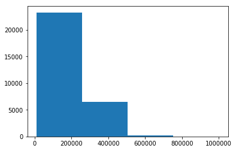

```python
plt.hist(credit['limit_bal'], bins = 4)
plt.show()
```

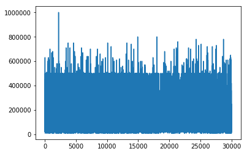

```python
plt.plot(credit['limit_bal'])
plt.show()
```

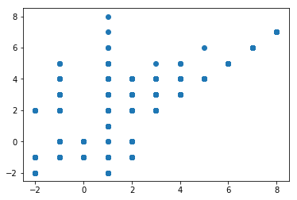

```python
plt.scatter(credit['pay_1'],credit['pay_2'])
plt.show()
```

```python
header = credit.dtypes.index
print(header)
```

```
Index(['limit_bal', 'sex', 'education', 'marriage', 'age', 'pay_1', 'pay_2',
       'pay_3', 'pay_4', 'pay_5', 'pay_6', 'bill_amt1', 'bill_amt2',
       'bill_amt3', 'bill_amt4', 'bill_amt5', 'bill_amt6', 'pay_amt1',
       'pay_amt2', 'pay_amt3', 'pay_amt4', 'pay_amt5', 'pay_amt6', 'default',
       'pay', 'bill_amt', 'pay_amt', 'balance', 'limit_balance_ratio'],
      dtype='object')
```

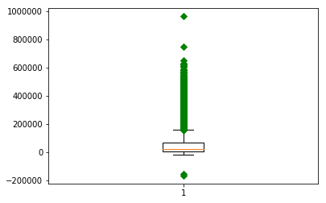

```python
plt.boxplot(credit['bill_amt1'],0,'gD')
plt.show()
```

#### Correlation between features and label

```python
corrMat = credit.corr()
print(corrMat)
```

```
                     limit_bal       age     pay_1     pay_2     pay_3  \
limit_bal             1.000000  0.144713 -0.271214 -0.296382 -0.286123
age                   0.144713  1.000000 -0.039447 -0.050148 -0.053048
pay_1                -0.271214 -0.039447  1.000000  0.672164  0.574245
pay_2                -0.296382 -0.050148  0.672164  1.000000  0.766552
pay_3                -0.286123 -0.053048  0.574245  0.766552  1.000000
pay_4                -0.267460 -0.049722  0.538841  0.662067  0.777359
pay_5                -0.249411 -0.053826  0.509426  0.622780  0.686775
pay_6                -0.235195 -0.048773  0.474553  0.575501  0.632684
bill_amt1             0.285430  0.056239  0.187068  0.234887  0.208473
bill_amt2             0.278314  0.054283  0.189859  0.235257  0.237295
bill_amt3             0.283236  0.053710  0.179785  0.224146  0.227494
bill_amt4             0.293988  0.051353  0.179125  0.222237  0.227202
bill_amt5             0.295562  0.049345  0.180635  0.221348  0.225145
bill_amt6             0.290389  0.047613  0.176980  0.219403  0.222327
pay_amt1              0.195236  0.026147 -0.079269 -0.080701  0.001295
pay_amt2              0.178408  0.021785 -0.070101 -0.058990 -0.066793
pay_amt3              0.210167  0.029247 -0.070561 -0.055901 -0.053311
pay_amt4              0.203242  0.021379 -0.064005 -0.046858 -0.046067
pay_amt5              0.217202  0.022850 -0.058190 -0.037093 -0.035863
pay_amt6              0.219595  0.019478 -0.058673 -0.036500 -0.035861
default              -0.153520  0.013890  0.324794  0.263551  0.235253
pay                  -0.316961 -0.058217  0.741345  0.850428  0.878080
bill_amt              0.302044  0.054981  0.191803  0.238182  0.235960
pay_amt               0.352655  0.040776 -0.116810 -0.092553 -0.071732
balance               0.256616  0.050634  0.220029  0.264440  0.258630
limit_balance_ratio  -0.367485 -0.035415  0.428476  0.510098  0.495820

                        pay_4     pay_5     pay_6  bill_amt1  bill_amt2  \
limit_bal           -0.267460 -0.249411 -0.235195   0.285430   0.278314
age                 -0.049722 -0.053826 -0.048773   0.056239   0.054283
pay_1                0.538841  0.509426  0.474553   0.187068   0.189859
pay_2                0.662067  0.622780  0.575501   0.234887   0.235257
pay_3                0.777359  0.686775  0.632684   0.208473   0.237295
pay_4                1.000000  0.819835  0.716449   0.202812   0.225816
pay_5                0.819835  1.000000  0.816900   0.206684   0.226913
pay_6                0.716449  0.816900  1.000000   0.207373   0.226924
bill_amt1            0.202812  0.206684  0.207373   1.000000   0.951484
bill_amt2            0.225816  0.226913  0.226924   0.951484   1.000000
bill_amt3            0.244983  0.243335  0.241181   0.892279   0.928326
```

[output cut: 86 more lines]

```
bill_amt6            0.909855             0.501908
pay_amt1             0.140549            -0.009291
pay_amt2             0.084425            -0.032873
pay_amt3             0.120386            -0.033401
pay_amt4             0.113271            -0.031158
pay_amt5             0.119555            -0.030683
pay_amt6             0.094586            -0.053560
default              0.003879             0.125141
pay                  0.307542             0.572519
bill_amt             0.987555             0.549729
pay_amt              0.191943            -0.056035
balance              1.000000             0.583939
limit_balance_ratio  0.583939             1.000000

[26 rows x 26 columns]
```

The features highest correlated to the default label include: pay, pay_1 and pay_2. Those three features all had a correlation value higher than 0.25 Other features correlating to the probability of default include: pay_3...pay_6, limit_balance_ratio, pay_amt and lim_bal.

```python
covMat = credit.cov()
print(covMat)
```

```
                        limit_bal            age         pay_1          pay_2  \
limit_bal            1.683446e+10  173076.722569 -39545.930009  -46037.648360
age                  1.730767e+05      84.969755     -0.408639      -0.553408
pay_1               -3.954593e+04      -0.408639      1.262930       0.904330
pay_2               -4.603765e+04      -0.553408      0.904330       1.433254
pay_3               -4.443225e+04      -0.585263      0.772384       1.098371
pay_4               -4.057181e+04      -0.535851      0.707972       0.926680
pay_5               -3.667056e+04      -0.562245      0.648743       0.844886
pay_6               -3.509308e+04      -0.517022      0.613292       0.792320
bill_amt1            2.727020e+09   38172.933546  15480.304170   20706.614217
bill_amt2            2.570130e+09   35613.657962  15185.916919   20045.829482
bill_amt3            2.548533e+09   34334.251320  14011.556537   18609.510991
bill_amt4            2.453926e+09   30453.108180  12950.248389   17116.298983
bill_amt5            2.331481e+09   27654.067800  12341.668685   16110.952468
bill_amt6            2.243837e+09   26137.648547  11844.759724   15642.875812
pay_amt1             4.195711e+08    3992.041735  -1475.495089   -1600.240756
pay_amt2             5.333504e+08    4626.861549  -1815.138407   -1627.192336
pay_amt3             4.801180e+08    4746.824393  -1396.168258   -1178.331282
pay_amt4             4.131202e+08    3087.324192  -1126.847945    -878.843879
pay_amt5             4.305657e+08    3218.052172   -999.107730    -678.468530
pay_amt6             5.065153e+08    3191.903901  -1172.193614    -776.835035
default             -8.267552e+03       0.053143      0.151499       0.130960
pay                 -2.423513e+05      -3.162428      4.909650       5.999841
bill_amt             1.487493e+10  192365.667355  81814.454424  108232.081954
pay_amt              2.783241e+09   22863.007942  -7984.951043   -6739.911818
balance              1.209169e+10  169502.659412  89799.405467  114971.993772
limit_balance_ratio -9.757162e+04      -0.668044      0.985372       1.249681

                             pay_3          pay_4          pay_5  \
limit_bal            -44432.253315  -40571.811859  -36670.562325
age                      -0.585263      -0.535851      -0.562245
pay_1                     0.772384       0.707972       0.648743
pay_2                     1.098371       0.926680       0.844886
pay_3                     1.432492       1.087761       0.931455
pay_4                     1.087761       1.366885       1.086161
pay_5                     0.931455       1.086161       1.284114
pay_6                     0.870815       0.963263       1.064545
bill_amt1             18373.210469   17460.198259   17246.377531
bill_amt2             20214.071495   18790.627741   18301.285286
bill_amt3             18882.491544   19862.999426   19122.663330
```

[output cut: 142 more lines]

```
bill_amt6                   61167.411779
pay_amt1                     -314.904266
pay_amt2                    -1549.984506
pay_amt3                    -1203.460355
pay_amt4                     -998.877573
pay_amt5                     -959.312220
pay_amt6                    -1948.459582
default                         0.106291
pay                             6.904213
bill_amt                   426990.516863
pay_amt                     -6974.998502
balance                    433965.515364
limit_balance_ratio             4.187626

[26 rows x 26 columns]
```

### Total defaults

```python
print(credit.groupby('default')['default'].count())
print('\n\nFraction of clients that defaulted: ' + str(round((6636/30000),2)))
```

```
default
0    23364
1     6636
Name: default, dtype: int64


Fraction of clients that defaulted: 0.22
```

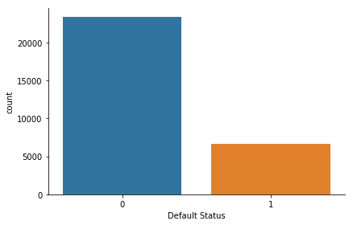

```python
sns.factorplot('default',data = credit, kind = 'count', aspect = 1.5).set_xlabels('Default Status')
```

More than 3 out of 4 clients pay their loans. It is a small fraction of clients that are the problem.

### `'sex'` statistics

```python
print(credit.groupby(['sex','default'])['sex'].count())

print('\nMales in data:\t\t' + str(9015+2873))
print('Females in data:\t' + str(14349+3763))

print('\nFraction of defaults pertaining to males:\t' + str(round((2873/(2873+3763)),2)))
print('Fraction of defaults pertaining to females:\t' + str(round((3763/(2873+3763)),2)))

print('\nFraction of males that defaulted:\t' + str(round((2873/(2873+9015)),2)))
print('Fraction of females that defaulted:\t' + str(round((3763/(14349+3763)),2)))
```

```
sex     default
female  0          14349
        1           3763
male    0           9015
        1           2873
Name: sex, dtype: int64

Males in data:		11888
Females in data:	18112

Fraction of defaults pertaining to males:	0.43
Fraction of defaults pertaining to females:	0.57

Fraction of males that defaulted:	0.24
Fraction of females that defaulted:	0.21
```

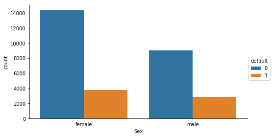

```python
sns.factorplot('sex', data = credit, hue = 'default', kind = 'count', aspect = 1.75).set_xlabels('Sex')
```

Data contains more females that males, therefore, they contribute to more defaults in the data set. However, males tend to default 3% more often than females.

### `'education'` statistics

```
education    default
graduate     0           8549
             1           2036
high_school  0           3680
             1           1237
other        0            435
             1             33
university   0          10700
             1           3330
Name: education, dtype: int64
```

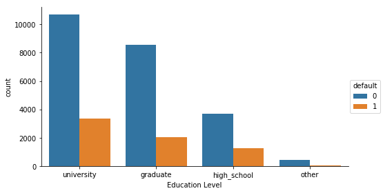

```python
print(credit.groupby(['education','default'])['education'].count())
sns.factorplot('education',data=credit,hue='default',kind='count',aspect=1.75).set_xlabels('Education Level')
```

```python
print('Fraction of people with graduate school education that defaulted:\t' + str(round((2036/(2036+8549)),2)))
print('\nFraction of people with university education that defaulted:\t\t' + str(round((3330/(3330+10700)),2)))
print('\nFraction of people with high school education that defaulted:\t\t' + str(round((1237/(3680+1237)),2)))
```

```
Fraction of people with graduate school education that defaulted:	0.19

Fraction of people with university education that defaulted:		0.24

Fraction of people with high school education that defaulted:		0.25
```

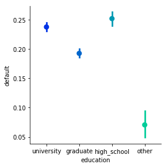

```python
sns.factorplot('education', 'default', data=credit, palette='winter')
```

University and high school level educated people defaulted about the same percentage of the time, 24 to 25%. However, people with graduate school education defaulted at a much lower rate, only 19%. Clients under other types of education defaulted at a really low rate; however, there is a low amount of data for these groups of people relative to the other education levels.

### `'marriage'` statistics

```
marriage  default
divorced  0            239
          1             84
married   0          10453
          1           3206
other     0             49
          1              5
single    0          12623
          1           3341
Name: marriage, dtype: int64
```

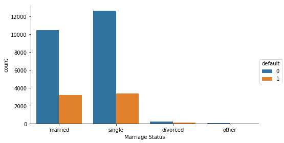

```python
print(credit.groupby(['marriage','default'])['marriage'].count())
sns.factorplot('marriage', data=credit, hue='default', kind='count', aspect=1.75).set_xlabels('Marriage Status')
```

```python
print('Fraction of married people that defaulted:\t' + str(round((3206/(3206+10453)),2)))
print('\nFraction of single people that defaulted:\t' + str(round((3341/(3341+12623)),2)))
print('\nFraction of divorced people that defaulted:\t' + str(round((84/(84+239)),2)))
```

```
Fraction of married people that defaulted:	0.23

Fraction of single people that defaulted:	0.21

Fraction of divorced people that defaulted:	0.26
```

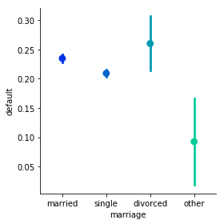

```python
sns.factorplot('marriage', 'default', data=credit, palette='winter')
```

Divorced people had the highest rate of defaulting, at 26%. Married people were second most likely to default, 23% of the time. Single people only defaulted 21% of the time. There was too little information about the default behavior of other marriage category clients to make any substantial conclusions about them.

### `'age'` statistics

```python
credit.age.describe()
```

```
count    30000.000000
mean        35.485500
std          9.217904
min         21.000000
25%         28.000000
50%         34.000000
75%         41.000000
max         79.000000
Name: age, dtype: float64
```

Average age is 35. Three out of four people are under 41 years old. Oldest client age is 79, and youngest 21.

```
Text(0.5,1,"Distribution of Clients' Ages")
```

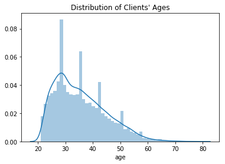

```python
sns.distplot(credit['age']).set_title("Distribution of Clients' Ages")
```

There is a positive skew in the age distribution; there are many more younger clients than there are older. This can be seen visually in the distribution above and in the statistics obtained from the describe() function.

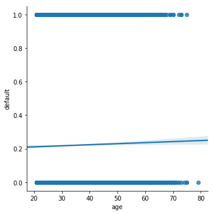

```python
sns.lmplot('age', 'default', data=credit)
```

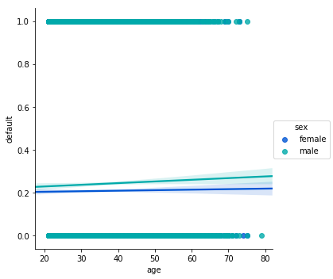

```python
sns.lmplot('age', 'default', hue='sex', data=credit, palette='winter')
```

There is no real correlation between the age of a client and their probability to default. From the linear plots above, it can be concluded that there might be a very small increase in probability of default as age increases. However, this is a very weak relationship.

## `'sex'` & `'education'` statistics

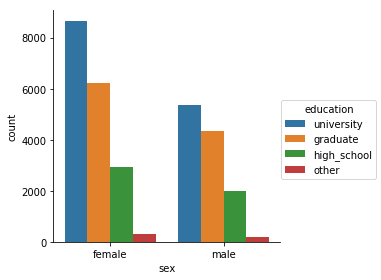

```python
sns.factorplot('sex',data=credit, kind='count',hue='education')
```

```python
### percentages of education making up the male clients
male_education = credit.loc[credit['sex'] == 'male', ['sex','education']]
(male_education['education'].value_counts())/len(male_education)
```

```
university     0.452052
graduate       0.366252
high_school    0.167396
other          0.014300
Name: education, dtype: float64
```

```python
### percentages of education making up the female clients
female_education = credit.loc[credit['sex'] == 'female', ['sex','education']]
(female_education['education'].value_counts())/len(female_education)
```

```
university     0.477915
graduate       0.344026
high_school    0.161606
other          0.016453
Name: education, dtype: float64
```

45% of males and 47% of females have a university education; this is not a significant difference. Another small difference is that males went to graduate school about 37% of the time, while only 34% of females did; this again, is a negligible observation given it could change with a different dataset or additional data.

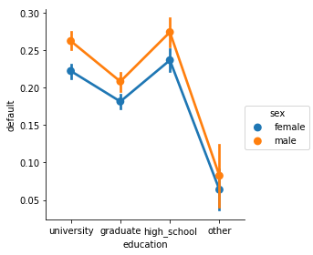

```python
sns.factorplot('education','default',hue='sex',data=credit)
```

Females and males have a proportional probability of defaulting based on their education. Both sexes have the highest probability of default when they only have a high school education. The second most likely client to default, will have a university education, and graduate level clients have the third highest likelyhood of defaulting. Any client categorized under "other" education has a very low probability of defaulting.

### `'pay'` statistics

```python
credit.pay.describe()
```

```
count    30000.000000
mean        -1.094633
std          5.893055
min        -12.000000
25%         -5.000000
50%          0.000000
75%          0.000000
max         36.000000
Name: pay, dtype: float64
```

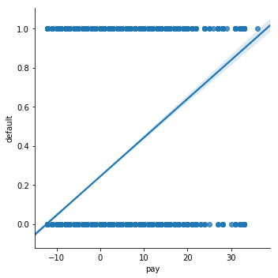

```python
sns.lmplot('pay', 'default', data=credit)
```

The `'pay'` has a very clear direct relationship with the probability of a client defaulting. The higher the client's `'pay'` value, the higher the probability that they will default. This makes sense, because the higher the `'pay'` value of a client is, the further behind they usually are on their repayment.

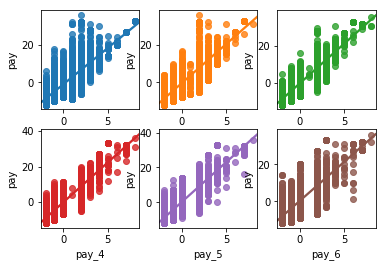

```python
fig, axs = plt.subplots(2,3)
sns.regplot(x = 'pay_1', y = 'pay', data = credit, ax = axs[0,0])
sns.regplot(x = 'pay_2', y = 'pay', data = credit, ax = axs[0,1])
sns.regplot(x = 'pay_3', y = 'pay', data = credit, ax = axs[0,2])
sns.regplot(x = 'pay_4', y = 'pay', data = credit, ax = axs[1,0])
sns.regplot(x = 'pay_5', y = 'pay', data = credit, ax = axs[1,1])
sns.regplot(x = 'pay_6', y = 'pay', data = credit, ax = axs[1,2])
```

As can be seen from the regression plots above, the `'pay'` feature is correlated to all the `'pay_n'` features. Therefore, since the '`pay'` feature is highly related to the probability of default, one could assume that the '`pay_n'` features would all be highly correlated to the probability of default as well. This is correct and can be seen from the regression plots below.

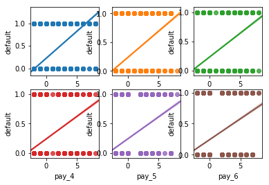

```python
fig, axs = plt.subplots(2,3)
sns.regplot(x = 'pay_1', y = 'default', data = credit, ax = axs[0,0])
sns.regplot(x = 'pay_2', y = 'default', data = credit, ax = axs[0,1])
sns.regplot(x = 'pay_3', y = 'default', data = credit, ax = axs[0,2])
sns.regplot(x = 'pay_4', y = 'default', data = credit, ax = axs[1,0])
sns.regplot(x = 'pay_5', y = 'default', data = credit, ax = axs[1,1])
sns.regplot(x = 'pay_6', y = 'default', data = credit, ax = axs[1,2])
```

### Balance related statistics

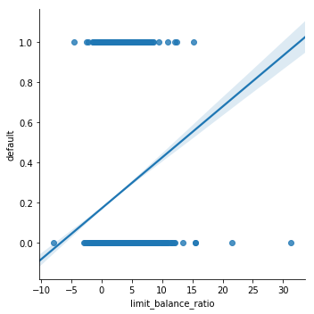

```python
sns.lmplot('limit_balance_ratio', 'default', data=credit)
```

The higher the limit balance to balance ratio is, the higher the probability of default. The `'balance'` of a client is calculated by subtracting their total `'pay_amt'` from their total `'bill_amt'`. Therefore, it makes sense that the closer a client is to their balance limit, the harder it is going to be for them to pay off their loans.

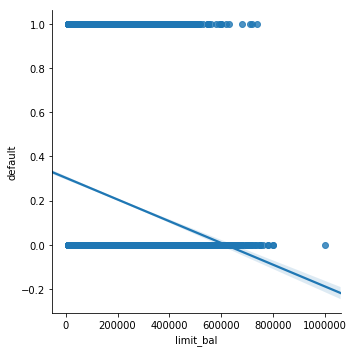

```python
sns.lmplot('limit_bal', 'default', data=credit)
```

As the `'limit_bal'` given to a person increases, the probability of default decreases. This makes sense, because usually the people given the most credit have the best probability of paying back their loans.

# Build & Evaluate Models

```python
# scipy, math, sklearn
from math import sqrt
import scipy
import sklearn

# estimators
from sklearn.tree import DecisionTreeClassifier
from sklearn.naive_bayes import GaussianNB
from sklearn.ensemble import RandomForestClassifier
from sklearn.linear_model import LogisticRegression

# performance metrics & pprint
from sklearn.metrics import accuracy_score
from sklearn.metrics import precision_score
from sklearn.metrics import recall_score
from sklearn.metrics import fbeta_score
import pprint

# cross validation
from sklearn.model_selection import GridSearchCV
from sklearn.model_selection import train_test_split

# ignore warnings
import warnings
warnings.filterwarnings("ignore")
```

```python
# features
features = credit[['pay','limit_bal','pay_amt','bill_amt','balance','limit_balance_ratio']]
features.head()
```

[output not shown]

```python
# label
label = credit['default']
label.head()
```

```
0    1
1    1
2    0
3    0
4    0
Name: default, dtype: int64
```

```python
# Train / Test Split
X_train, X_test, y_train, y_test = train_test_split(features, label)
X_train.shape, X_test.shape
```

```
((22500, 6), (7500, 6))
```

```python
# models
modelDT = DecisionTreeClassifier()
modelNB = GaussianNB()
modelRF = RandomForestClassifier()
modelLR = LogisticRegression()
```

```python
# performance metrics available
sklearn.metrics.SCORERS.keys()
```

[output not shown]

```python
# relevant performance metrics
scoring = {'accuracy':'accuracy',
          'precision':'precision',
          'recall':'recall',
          'f1':'f1'}
```

```python
# Decision Tree Classifier Fitting
params_DT = {'max_depth':[5,25,125],'min_samples_split':[2,20,200]}
DT_CV = GridSearchCV(estimator = modelDT, param_grid = params_DT, scoring = scoring, refit = False)
DT_CV.fit(X_train, y_train)
print('Decision Tree Classifier Fitted')
```

```
Decision Tree Classifier Fitted
```

```python
# Decision Tree Classifier GridSearchCV Results
results_DT = DT_CV.cv_results_
for i in range(len(results_DT['params'])):
    print(results_DT['params'][i])
    print('Average Accuracy Score:\t', results_DT['mean_test_accuracy'][i])
    print('Average F1 Score:\t', results_DT['mean_test_f1'][i])
    print('Average Precision Score:', results_DT['mean_test_precision'][i])
    print('Average Recall Score:\t', results_DT['mean_test_recall'][i],'\n')
```

```
{'max_depth': 5, 'min_samples_split': 2}
Average Accuracy Score:	 0.8044
Average F1 Score:	 0.40409918190994004
Average Precision Score: 0.6181178147983049
Average Recall Score:	 0.3010809952893651

{'max_depth': 5, 'min_samples_split': 20}
Average Accuracy Score:	 0.8044
Average F1 Score:	 0.40409918190994004
Average Precision Score: 0.6181178147983049
Average Recall Score:	 0.3010809952893651

{'max_depth': 5, 'min_samples_split': 200}
Average Accuracy Score:	 0.8041333333333334
Average F1 Score:	 0.40867706700944467
Average Precision Score: 0.6135973329857023
Average Recall Score:	 0.30671394834713633

{'max_depth': 25, 'min_samples_split': 2}
Average Accuracy Score:	 0.7302666666666666
Average F1 Score:	 0.3703316305627687
Average Precision Score: 0.3824704257757761
Average Recall Score:	 0.35900891064434276

{'max_depth': 25, 'min_samples_split': 20}
Average Accuracy Score:	 0.7544888888888889
Average F1 Score:	 0.37615556078200163
Average Precision Score: 0.42909864280587456
Average Recall Score:	 0.33587529308914094

{'max_depth': 25, 'min_samples_split': 200}
Average Accuracy Score:	 0.7951555555555555
Average F1 Score:	 0.41146407946946606
Average Precision Score: 0.5642694741008139
Average Recall Score:	 0.32501465707375393

{'max_depth': 125, 'min_samples_split': 2}
Average Accuracy Score:	 0.7171555555555555
Average F1 Score:	 0.36447033492627295
Average Precision Score: 0.3619480782067486
Average Recall Score:	 0.3670545275019722

{'max_depth': 125, 'min_samples_split': 20}
Average Accuracy Score:	 0.7496444444444444
Average F1 Score:	 0.3728005546254515
Average Precision Score: 0.41739765430654724
Average Recall Score:	 0.3372849090385676

{'max_depth': 125, 'min_samples_split': 200}
Average Accuracy Score:	 0.7943555555555556
Average F1 Score:	 0.40975168596437517
Average Precision Score: 0.5607808006808187
Average Recall Score:	 0.3240089573486819
```

```python
# Random Forest Classifier Fitting
params_RF = {'n_estimators':[10,100],'max_depth':[5,25,125],'min_samples_split':[2,20,200]}
RF_CV = GridSearchCV(estimator = modelRF, param_grid = params_RF, scoring = scoring, refit = False)
RF_CV.fit(X_train, y_train)
print('Random Forest Classifier Fitted')
```

```
Random Forest Classifier Fitted
```

```python
# Random Forest Classifier GridSearchCV Results
results_RF = RF_CV.cv_results_
for i in range(len(results_RF['params'])):
    print(results_RF['params'][i])
    print('Average Accuracy Score:\t', results_RF['mean_test_accuracy'][i])
    print('Average F1 Score:\t', results_RF['mean_test_f1'][i])
    print('Average Precision Score:', results_RF['mean_test_precision'][i])
    print('Average Recall Score:\t', results_RF['mean_test_recall'][i],'\n')
```

```
{'max_depth': 5, 'min_samples_split': 2, 'n_estimators': 10}
Average Accuracy Score:	 0.8045333333333333
Average F1 Score:	 0.3776025009616537
Average Precision Score: 0.6343892868405394
Average Recall Score:	 0.2727196485413549

{'max_depth': 5, 'min_samples_split': 2, 'n_estimators': 100}
Average Accuracy Score:	 0.8044
Average F1 Score:	 0.3912821892159068
Average Precision Score: 0.6276274228759267
Average Recall Score:	 0.2849963387324811

{'max_depth': 5, 'min_samples_split': 20, 'n_estimators': 10}
Average Accuracy Score:	 0.8058666666666666
Average F1 Score:	 0.3984078154172013
Average Precision Score: 0.6355409569930783
Average Recall Score:	 0.2920408607640438

{'max_depth': 5, 'min_samples_split': 20, 'n_estimators': 100}
Average Accuracy Score:	 0.8049777777777778
Average F1 Score:	 0.400004647632594
Average Precision Score: 0.6264325173863889
Average Recall Score:	 0.29525327133805507

{'max_depth': 5, 'min_samples_split': 200, 'n_estimators': 10}
Average Accuracy Score:	 0.8039555555555555
Average F1 Score:	 0.36990843875281565
Average Precision Score: 0.6415012899106002
Average Recall Score:	 0.26227579855400973

{'max_depth': 5, 'min_samples_split': 200, 'n_estimators': 100}
Average Accuracy Score:	 0.8058222222222222
Average F1 Score:	 0.39951502992491517
Average Precision Score: 0.6318702542997686
Average Recall Score:	 0.29304023120184725

{'max_depth': 25, 'min_samples_split': 2, 'n_estimators': 10}
Average Accuracy Score:	 0.7802666666666667
Average F1 Score:	 0.3668435255379376
Average Precision Score: 0.5047376959198564
```

[output cut: 52 more lines]

```
Average F1 Score:	 0.404749629061825
Average Precision Score: 0.5834032738327994
Average Recall Score:	 0.30993380715508206

{'max_depth': 125, 'min_samples_split': 200, 'n_estimators': 10}
Average Accuracy Score:	 0.8043111111111111
Average F1 Score:	 0.41241139020250983
Average Precision Score: 0.6135543773079232
Average Recall Score:	 0.31154127002962173

{'max_depth': 125, 'min_samples_split': 200, 'n_estimators': 100}
Average Accuracy Score:	 0.8063555555555556
Average F1 Score:	 0.4146222774909637
Average Precision Score: 0.6248960681324275
Average Recall Score:	 0.3107385879840105
```

##### Gaussian Naive Bayes does not have relevant parameter tuning

```python
# Gaussian Naive Bayes Classifier
modelNB.fit(X_train, y_train)
NB_CV = cross_validate(modelNB, X_train, y_train, scoring = scoring)
print('Average Accuracy Score:\t', np.mean(NB_CV['test_accuracy']))
print('Average Precision Score:', np.mean(NB_CV['test_precision']))
print('Average Recall Score:\t', np.mean(NB_CV['test_recall']))
print('Average F1 Score:\t', np.mean(NB_CV['test_f1']))
```

```
Average Accuracy Score:	 0.7798219766289339
Average Precision Score: 0.5780626780626781
Average Recall Score:	 0.034997436276361885
Average F1 Score:	 0.06529645711553543
```

The accuracy score lets us know how many clients were correctly identified as either defaulting or not defaulting for all the predictions. The precision score lets us know how many of the clients classified as defaulting are actually defaulting. Recall lets us know how many of the defaulting customers were predicted to default. The F1 score combines the precision and recall to give us one score. Precision is important, because we do not want to overclassify potential good customers as defaulting customers. Recall is important, because we do not want to give out loans to customers that are likely to default. Therefore, the accuracy score and f1 score will give us a pretty good idea of which model to choose. Based on the accuracy and f1 score, the Random Forest Classifier with a `max_depth: 125`, `'min_samples_split': 200` and `'n_estimators': 100` is the best model.

```python
# Best Model
best_model = RandomForestClassifier(max_depth = 125, min_samples_split = 200, n_estimators = 100)
best_model.fit(X_train,y_train)
```

```
RandomForestClassifier(bootstrap=True, class_weight=None, criterion='gini',
            max_depth=125, max_features='auto', max_leaf_nodes=None,
            min_impurity_decrease=0.0, min_impurity_split=None,
            min_samples_leaf=1, min_samples_split=200,
            min_weight_fraction_leaf=0.0, n_estimators=100, n_jobs=None,
            oob_score=False, random_state=None, verbose=0,
            warm_start=False)
```

```python
# predictions
predictions = best_model.predict(X_test)
```

```python
# performance
print('Accuracy:\t', mt.accuracy_score(y_test,predictions))
print('Precision:\t', mt.precision_score(y_test,predictions))
print('Recall:\t\t', mt.recall_score(y_test,predictions))
print('F1 Score:\t', mt.f1_score(y_test,predictions))
```

```
Accuracy:	 0.8034666666666667
Precision:	 0.6196473551637279
Recall:		 0.2956730769230769
F1 Score:	 0.40032546786004874
```